# stocks_risk and return

20/10/23 portfolio_projects/project_a **Stock Risk and Return** ref udemy business_finance course, section 297: importing stock price data Stocks to analyse: 1)Exxon Mobil Corp, 2)Boeing Co, 3)American Airlines Group, 4)johnson & johnson, 5)Apple, 6)Walt Disney

```
                         **Risk and Return of stock investments**
```

This project analyses the historical risk and return of 6 stocks from public companies during a period of 1 year, commencing January 2022.

Stocks are an investment product that give the stockholder a share in the ownership of the companies issuing the stocks. Investors buy stocks with the aim of increasing their capital through: a) an increase in the price of the stocks they have bought and/or b) receipt of payments (dividends) from earnings of the companies for which they hold stocks.

Like so many other products and services, stock prices are driven by supply and demand. Some of the factors that can affect the supply - demand dynamics of stocks include: company issues, state of the economy, national and international politics. As stock prices move up as well as down, there is no guarantee that a company's stock price will grow and that a company will pay a dividend. At times stock prices can drop significantly, say by more than 10%, over a short period causing some impatient investors to sell their stocks and thus incurr losses. Companies can also fail, it is therefore possible that an investor can lose all the money invested in stocks.

Each investment product, such as cash, stocks, bonds etc has its own level Risk and Return features. The relationship between Risk and Return on an investment is that investors taking on greater risk will seek greater potential reward. Similarily, the lower the risk, lower is the potential return. For example, an investor can invest in shares of start_up company (high risk) and lose everything or make a fortune (high reward). Alternatively, investing in an established company with a track record of steady growth (low risk) an investor is unlikely to loose all his money but is also less likely to make a fortune. Therefore, investing requires individuals to take on certain amount of risk depending on their financial goals and risk appitite. Historically, investors have gained significant capital growth by investing in stocks. This has only been achieved by investing with patience and over a long term. Investing over longer term allow stock markets to recover temporary losses and deliver positve returns.

Dataset: Stocks data is collected the Yahoo finance website.

Company name and ticker symbols:

```
1)Exxon Mobil Corp (XOM)
2)Boeing CoN(BA)
3)American Airlines Group (AAL)
4)johnson & johnson (JNJ)
5)Apple (AAPL)
6)Walt Disney (DIS).
```

```python
# import the necessary libraries for financial data analysis of stocks.
import numpy as np
import pandas as pd
import yfinance as yf
import matplotlib.pyplot as plt
import seaborn as sns
```

```python
# create a list of stocks to analyse by listing stock ticker symbols.

ticker = ["XOM", "BA", "AAL", "JNJ", "AAPL", "DIS"]
```

```python
# Download historical stock price data for the above stocks for the year 2022.
stocks = yf.download(ticker, start = "2022-01-01", end = "2022-12-31" )
```

```
[*********************100%***********************]  6 of 6 completed
```

```python
# lets explore the downloaded data from Yahoo

stocks.head() # view the first 5 rows of our stocks data
```

| Date | Adj Close AAL | Adj Close AAPL | Adj Close BA | Adj Close DIS | Adj Close JNJ | Adj Close XOM | Close AAL | Close AAPL | Close BA | Close DIS | ... | Open BA | Open DIS | Open JNJ | Open XOM | Volume AAL | Volume AAPL | Volume BA | Volume DIS | Volume JNJ | Volume XOM |
| --- | --- | --- | --- | --- | --- | --- | --- | --- | --- | --- | --- | --- | --- | --- | --- | --- | --- | --- | --- | --- | --- |
| 2022-01-03 | 18.750000 | 180.190964 | 207.860001 | 156.759995 | 163.524780 | 59.638226 | 18.750000 | 182.009995 | 207.860001 | 156.759995 | ... | 204.000000 | 155.830002 | 170.210007 | 61.240002 | 42781000 | 104487900 | 9060200 | 10222800 | 6012200 | 24282400 |
| 2022-01-04 | 19.020000 | 177.904053 | 213.630005 | 155.729996 | 163.086258 | 61.881462 | 19.020000 | 179.699997 | 213.630005 | 155.729996 | ... | 211.300003 | 158.589996 | 171.059998 | 64.129997 | 29266600 | 99310400 | 11414600 | 16582000 | 6748400 | 38584000 |
| 2022-01-05 | 18.680000 | 173.171829 | 213.070007 | 155.190002 | 164.172989 | 62.651112 | 18.680000 | 174.919998 | 213.070007 | 155.190002 | ... | 216.639999 | 156.520004 | 172.000000 | 66.500000 | 34447900 | 94537600 | 11564700 | 12272100 | 7016100 | 34033300 |
| 2022-01-06 | 18.570000 | 170.281006 | 211.339996 | 156.899994 | 163.610565 | 64.124702 | 18.570000 | 172.000000 | 211.339996 | 156.899994 | ... | 214.639999 | 156.240005 | 172.149994 | 68.000000 | 19097700 | 96904000 | 7142200 | 11095300 | 7301600 | 30668500 |
| 2022-01-07 | 19.280001 | 170.449326 | 215.500000 | 157.830002 | 165.822144 | 64.650314 | 19.280001 | 172.169998 | 215.500000 | 157.830002 | ... | 212.979996 | 156.899994 | 171.460007 | 68.519997 | 42399500 | 86709100 | 9526400 | 9554600 | 6986000 | 23985400 |

5 rows × 36 columns

From above, we have a columns with a multilevel (2 level) header consisting of an inner and an outer level. The inner level identifies the ticker symbols and the outter level shows the Adj Close, Close, Open etc price of the stocks. Two "Close" prices are shown. The Close price is the last traing price of the day and Adj Close price is the price after dividend payouts, issue of additional shares and stock splits have been taken into account. Adj Close price is a thus a better parameter for stock returns than the Close price. It should be noted that the first record occurs on 2022-01-03, which is the first trading day of the year and not the start date specified in the download request.

```python
stocks.tail() # view the last 5 rows of the stocks data
```

| Date | Adj Close AAL | Adj Close AAPL | Adj Close BA | Adj Close DIS | Adj Close JNJ | Adj Close XOM | Close AAL | Close AAPL | Close BA | Close DIS | ... | Open BA | Open DIS | Open JNJ | Open XOM | Volume AAL | Volume AAPL | Volume BA | Volume DIS | Volume JNJ | Volume XOM |
| --- | --- | --- | --- | --- | --- | --- | --- | --- | --- | --- | --- | --- | --- | --- | --- | --- | --- | --- | --- | --- | --- |
| 2022-12-23 | 12.71 | 131.299820 | 189.059998 | 88.010002 | 173.632370 | 106.052940 | 12.71 | 131.860001 | 189.059998 | 88.010002 | ... | 188.250000 | 86.059998 | 176.669998 | 106.949997 | 17181200 | 63814900 | 3983600 | 11171600 | 3683400 | 11539400 |
| 2022-12-27 | 12.53 | 129.477600 | 189.399994 | 86.370003 | 173.583450 | 107.526436 | 12.53 | 130.029999 | 189.399994 | 86.370003 | ... | 189.580002 | 87.419998 | 178.110001 | 109.269997 | 18878200 | 69007800 | 5014800 | 11561400 | 3067300 | 11962100 |
| 2022-12-28 | 12.32 | 125.504539 | 188.380005 | 84.169998 | 172.830170 | 105.760185 | 12.32 | 126.040001 | 188.380005 | 84.169998 | ... | 189.320007 | 86.080002 | 177.759995 | 109.910004 | 20470400 | 85438400 | 4426300 | 12399500 | 2645400 | 10702100 |
| 2022-12-29 | 12.70 | 129.059387 | 188.910004 | 87.180000 | 173.710663 | 106.560371 | 12.70 | 129.610001 | 188.910004 | 87.180000 | ... | 189.000000 | 85.250000 | 177.550003 | 107.989998 | 19706300 | 75703700 | 4518900 | 13045100 | 2828800 | 10534000 |
| 2022-12-30 | 12.72 | 129.378006 | 190.490005 | 86.879997 | 172.820358 | 107.633774 | 12.72 | 129.929993 | 190.490005 | 86.879997 | ... | 187.500000 | 85.730003 | 177.490005 | 108.610001 | 19002800 | 77034200 | 4007400 | 23231000 | 4216600 | 11799600 |

5 rows × 36 columns

The last trading day shown above is 30th Dec 2022 and as before, we have a 2 level column header index.

```python
# examine the stocks dataframe in a little more detail

stocks.info()
```

```
<class 'pandas.core.frame.DataFrame'>
DatetimeIndex: 251 entries, 2022-01-03 to 2022-12-30
Data columns (total 36 columns):
 #   Column             Non-Null Count  Dtype
---  ------             --------------  -----
 0   (Adj Close, AAL)   251 non-null    float64
 1   (Adj Close, AAPL)  251 non-null    float64
 2   (Adj Close, BA)    251 non-null    float64
 3   (Adj Close, DIS)   251 non-null    float64
 4   (Adj Close, JNJ)   251 non-null    float64
 5   (Adj Close, XOM)   251 non-null    float64
 6   (Close, AAL)       251 non-null    float64
 7   (Close, AAPL)      251 non-null    float64
 8   (Close, BA)        251 non-null    float64
 9   (Close, DIS)       251 non-null    float64
```

[output cut: 28 more lines]

```python
# save the stocks dataframe to a csv file

stocks.to_csv("stocks.csv")
```

```python
# read back the "stocks.csv" file

stocks = pd.read_csv("stocks.csv", header = [0,1], index_col = 0, parse_dates = [0])
```

```python
stocks.head()
```

| Date | Adj Close AAL | Adj Close AAPL | Adj Close BA | Adj Close DIS | Adj Close JNJ | Adj Close XOM | Close AAL | Close AAPL | Close BA | Close DIS | ... | Open BA | Open DIS | Open JNJ | Open XOM | Volume AAL | Volume AAPL | Volume BA | Volume DIS | Volume JNJ | Volume XOM |
| --- | --- | --- | --- | --- | --- | --- | --- | --- | --- | --- | --- | --- | --- | --- | --- | --- | --- | --- | --- | --- | --- |
| 2022-01-03 | 18.750000 | 180.190964 | 207.860001 | 156.759995 | 163.524780 | 59.638226 | 18.750000 | 182.009995 | 207.860001 | 156.759995 | ... | 204.000000 | 155.830002 | 170.210007 | 61.240002 | 42781000 | 104487900 | 9060200 | 10222800 | 6012200 | 24282400 |
| 2022-01-04 | 19.020000 | 177.904053 | 213.630005 | 155.729996 | 163.086258 | 61.881462 | 19.020000 | 179.699997 | 213.630005 | 155.729996 | ... | 211.300003 | 158.589996 | 171.059998 | 64.129997 | 29266600 | 99310400 | 11414600 | 16582000 | 6748400 | 38584000 |
| 2022-01-05 | 18.680000 | 173.171829 | 213.070007 | 155.190002 | 164.172989 | 62.651112 | 18.680000 | 174.919998 | 213.070007 | 155.190002 | ... | 216.639999 | 156.520004 | 172.000000 | 66.500000 | 34447900 | 94537600 | 11564700 | 12272100 | 7016100 | 34033300 |
| 2022-01-06 | 18.570000 | 170.281006 | 211.339996 | 156.899994 | 163.610565 | 64.124702 | 18.570000 | 172.000000 | 211.339996 | 156.899994 | ... | 214.639999 | 156.240005 | 172.149994 | 68.000000 | 19097700 | 96904000 | 7142200 | 11095300 | 7301600 | 30668500 |
| 2022-01-07 | 19.280001 | 170.449326 | 215.500000 | 157.830002 | 165.822144 | 64.650314 | 19.280001 | 172.169998 | 215.500000 | 157.830002 | ... | 212.979996 | 156.899994 | 171.460007 | 68.519997 | 42399500 | 86709100 | 9526400 | 9554600 | 6986000 | 23985400 |

5 rows × 36 columns

```python
# create a new dataframe to examine the Adj Close price and then determine the stock returns based on the Adj Close price

adjclose = stocks.loc[:,"Adj Close"]
```

```python
# Examine the new dataframe

adjclose.info()
```

```
<class 'pandas.core.frame.DataFrame'>
DatetimeIndex: 251 entries, 2022-01-03 to 2022-12-30
Data columns (total 6 columns):
 #   Column  Non-Null Count  Dtype
---  ------  --------------  -----
 0   AAL     251 non-null    float64
 1   AAPL    251 non-null    float64
 2   BA      251 non-null    float64
 3   DIS     251 non-null    float64
 4   JNJ     251 non-null    float64
 5   XOM     251 non-null    float64
dtypes: float64(6)
memory usage: 13.7 KB
```

adjclose dataframe now has only 6 columns. Uses 13.7 KB of memory, has no missing values, floating point datatype for stock prices.

```python
# the first 5rows of the new "adjclose" dataframe.
# It is easier to read and doesn't have the extra data which isnt needed for this exercise.

adjclose.head()
```

| Date | AAL | AAPL | BA | DIS | JNJ | XOM |
| --- | --- | --- | --- | --- | --- | --- |
| 2022-01-03 | 18.750000 | 180.190964 | 207.860001 | 156.759995 | 163.524780 | 59.638226 |
| 2022-01-04 | 19.020000 | 177.904053 | 213.630005 | 155.729996 | 163.086258 | 61.881462 |
| 2022-01-05 | 18.680000 | 173.171829 | 213.070007 | 155.190002 | 164.172989 | 62.651112 |
| 2022-01-06 | 18.570000 | 170.281006 | 211.339996 | 156.899994 | 163.610565 | 64.124702 |
| 2022-01-07 | 19.280001 | 170.449326 | 215.500000 | 157.830002 | 165.822144 | 64.650314 |

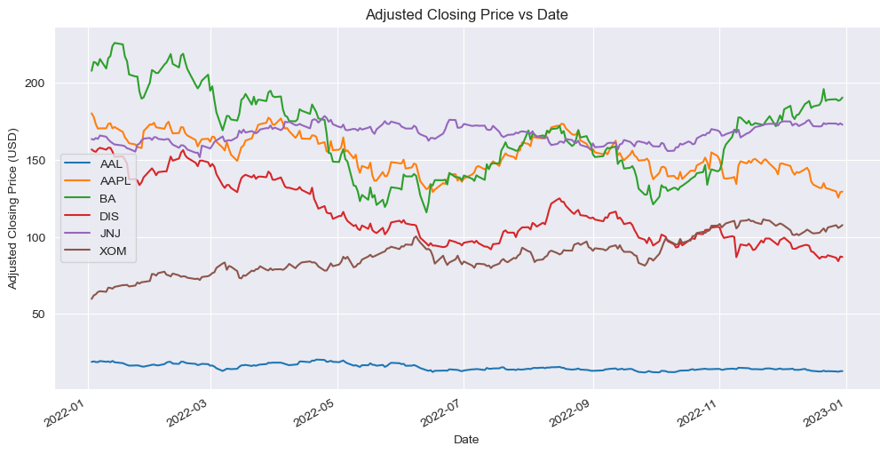

```python
# visualise the dataframe using the plot method

sns.set_style('darkgrid')
adjclose.plot(figsize = (12, 6))
plt.title("Adjusted Closing Price vs Date")
plt.ylabel("Adjusted Closing Price (USD)")
plt.show()
```

```python
# Normalise plots to a base value of 100, starting point on the y-axis at the start of trading.
# use pandas vectorisation feature to produce a new dataframe

norm = adjclose.div(adjclose.iloc[0]).mul(100)
norm.head()
```

| Date | AAL | AAPL | BA | DIS | JNJ | XOM |
| --- | --- | --- | --- | --- | --- | --- |
| 2022-01-03 | 100.000000 | 100.000000 | 100.000000 | 100.000000 | 100.000000 | 100.000000 |
| 2022-01-04 | 101.440002 | 98.730840 | 102.775909 | 99.342945 | 99.731831 | 103.761407 |
| 2022-01-05 | 99.626668 | 96.104613 | 102.506498 | 98.998474 | 100.396398 | 105.051938 |
| 2022-01-06 | 99.039998 | 94.500303 | 101.674202 | 100.089308 | 100.052460 | 107.522821 |
| 2022-01-07 | 102.826670 | 94.593714 | 103.675551 | 100.682577 | 101.404902 | 108.404155 |

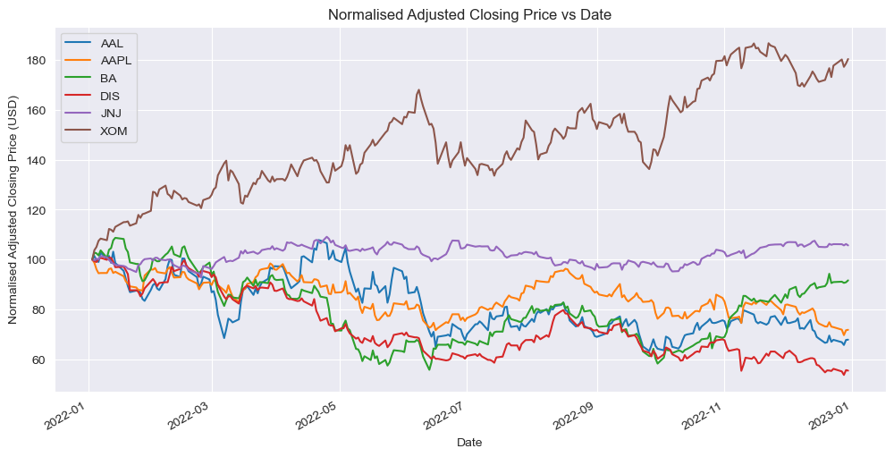

```python
# plot the graph with normalised dataframe

sns.set_style('darkgrid')
norm.plot(figsize = (12,6))
plt.title("Normalised Adjusted Closing Price vs Date")
plt.ylabel("Normalised Adjusted Closing Price (USD)")
plt.show()
```

The best perofming stock seems to be Exxon Mobil Corp (XOM) making a significant gain, from 100 dollars (USD) to about 180 dollars (USD) at the end of our given time period. Worst performing stock appears to be Disney (DIS), it has lost value from 100 dollars (USD) to about 50 dollars (USD). Johnson & Johnson has maintained a steady and stable performance. However, when comparing financial performance, the risk of achieveing that performance should also be considered. A higher risk should be rewarded with higher return and vise versa. The two metrics that can be used to measure return and risk are the mean return and the standard deviation of return.

```python
# calculate the daily returns for the above stocks using the pct_change() method and save in datafram called ret
# dropna() drops the first row which contains NaN values

ret = adjclose.pct_change().dropna()
```

```python
ret.head() # view stock price changes for first 5 rows
```

| Date | AAL | AAPL | BA | DIS | JNJ | XOM |
| --- | --- | --- | --- | --- | --- | --- |
| 2022-01-04 | 0.014400 | -0.012692 | 0.027759 | -0.006571 | -0.002682 | 0.037614 |
| 2022-01-05 | -0.017876 | -0.026600 | -0.002621 | -0.003467 | 0.006664 | 0.012437 |
| 2022-01-06 | -0.005889 | -0.016693 | -0.008119 | 0.011019 | -0.003426 | 0.023521 |
| 2022-01-07 | 0.038234 | 0.000988 | 0.019684 | 0.005927 | 0.013517 | 0.008197 |
| 2022-01-10 | -0.025415 | 0.000116 | -0.028724 | -0.007793 | -0.004944 | -0.005952 |

```python
# view the summary statistics of the ret dataframe

ret.describe()
```

|  | AAL | AAPL | BA | DIS | JNJ | XOM |
| --- | --- | --- | --- | --- | --- | --- |
| count | 250.000000 | 250.000000 | 250.000000 | 250.000000 | 250.000000 | 250.000000 |
| mean | -0.000925 | -0.001074 | 0.000085 | -0.002083 | 0.000281 | 0.002607 |
| std | 0.035447 | 0.022471 | 0.029455 | 0.023378 | 0.010986 | 0.022031 |
| min | -0.119945 | -0.058680 | -0.104701 | -0.131632 | -0.029919 | -0.078853 |
| 25% | -0.025697 | -0.015816 | -0.015116 | -0.016524 | -0.006702 | -0.010045 |
| 50% | -0.002061 | -0.001360 | 0.000601 | -0.003066 | -0.000117 | 0.004221 |
| 75% | 0.019172 | 0.013388 | 0.016238 | 0.011394 | 0.006613 | 0.016838 |
| max | 0.106246 | 0.088975 | 0.094630 | 0.062963 | 0.049703 | 0.064113 |

The mean and standard deviation of daily returns for the above stocks is shown in the second and third rows. Count of 250 is now the number of unique entries of the ret dataframe. This is 1 less than the original number of entries due to 1 entry dropped earlier.

```python
# show only the mean and the std values for the dataframe and save in variable summary
# Transpose the dataframe to show the mean and std values in columns

summary = ret.describe().T.iloc[:,1:3]
summary
```

|  | mean | std |
| --- | --- | --- |
| AAL | -0.000925 | 0.035447 |
| AAPL | -0.001074 | 0.022471 |
| BA | 0.000085 | 0.029455 |
| DIS | -0.002083 | 0.023378 |
| JNJ | 0.000281 | 0.010986 |
| XOM | 0.002607 | 0.022031 |

```python
# calulate the mean annual return and std (assume 252 trading days per year)
# over write the mean and std columns for the annual data

summary["mean"] = summary["mean"]*252
summary["std"] = summary["std"]*np.sqrt(252)
```

```python
summary # display the mean return and std data
```

|  | mean | std |
| --- | --- | --- |
| AAL | -0.233077 | 0.562705 |
| AAPL | -0.270522 | 0.356721 |
| BA | 0.021544 | 0.467590 |
| DIS | -0.524827 | 0.371120 |
| JNJ | 0.070834 | 0.174404 |
| XOM | 0.656964 | 0.349732 |

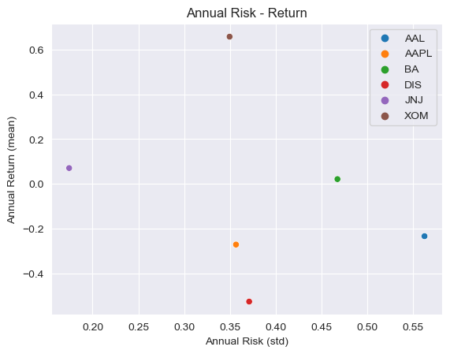

```python
# show the annualised mean and std data on a scatter plot

sns.set_style('darkgrid')
sns.scatterplot(data = summary, x = "std", y = "mean", hue = summary.index)
plt.title("Annual Risk - Return")
plt.xlabel("Annual Risk (std)")
plt.ylabel("Annual Return (mean)")

plt.show()
```

By investing in higher risk stocks in the hope of making greater returns doesn't mean that high returns are guaranteed!

**correlation** Lets examine our stocks returns further to see if there is some relationship between these stock returns by creating a correlation matrix and then visualising this as a heatmap.

```python
# correlation matrix

ret.corr()
```

|  | AAL | AAPL | BA | DIS | JNJ | XOM |
| --- | --- | --- | --- | --- | --- | --- |
| AAL | 1.000000 | 0.578066 | 0.701348 | 0.584744 | 0.169199 | 0.117557 |
| AAPL | 0.578066 | 1.000000 | 0.534268 | 0.653819 | 0.365951 | 0.272654 |
| BA | 0.701348 | 0.534268 | 1.000000 | 0.548247 | 0.120699 | 0.228948 |
| DIS | 0.584744 | 0.653819 | 0.548247 | 1.000000 | 0.210859 | 0.281361 |
| JNJ | 0.169199 | 0.365951 | 0.120699 | 0.210859 | 1.000000 | 0.088435 |
| XOM | 0.117557 | 0.272654 | 0.228948 | 0.281361 | 0.088435 | 1.000000 |

In a correlation matrix cell values have a range of -1 to +1. Values near 0 means there is no linear trend between two stocks returns, such as XOM and JNJ. Two stock returns that have a cell value greater than 0 indicate that they are positvely correlated ie as one stock return increases so does the other. The closer a cell value is to 1, the stronger the relationship between the stocks. A correlation of 1, along the diagonal, means each stock return is correlating with itself (perfect correlation ie moving in the same direction with the same magnitude). In negative correlations (negative cell values), as one stock return increases the other stock return decreases, and vice versa. When a correlation matrix contains a lot of numerical data it can be difficult and time consuming to see relationships and general trends between variables, eg stocks returns. Graphical representations such as Heatmaps (see below) are utilised to overcome these issues.

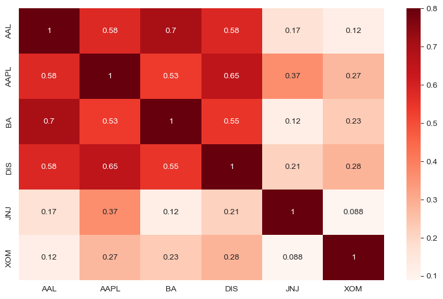

```python
# heatmap of the ret correlation matrix

plt.figure(figsize = (10,6))
sns.heatmap(ret.corr(), cmap = "Reds", annot = True, vmax = 0.8)
plt.show()
```

It is much easier to visualise and analyse data in the form of a heatmap than a numerical correlation matrix. Darker the cell colour greater the correlation between a pair of stocks and vise versa. Highest positive correlation (0.7, dark red coloured cells) occurs between AAL and BA. Light colour cells indicate low positive correlation as in the case of : a) XOM and each of the other stocks ie these stocks appear to be indepenedent of from XOM. b) JNJ and each of the other stocks ie these stocks appear to be indepenedent of from JNJ.

Negative or low correlation between a pair of stocks reduces risk because as the price of one stock falls it may be compensated by a rise in the price of the other (-ve correction) or at least a lesser drop. In this way investors aim to achieve better returns with an acceptable level of risk.